## Result1

What I’m also thinking is creating a model to display a similar result but now to see whether the trend of first registration has been overall ascending and favouring the newer cars to be registered more.

For this a linear model is first created where the following notation is established: Count i=β0+β1⋅Year i+εi, where the number of registered cars is equal to and β 1, which is additive change per year and εi the error term. When creating this we assume that variance of the counts is equal to the total variance, but this data does not have constant variance, which is required for linear model, but we’re trying to see the fit to move forward

```r
#Probabilities are calculated for each year and divided by the total number of cars.
model1 <-  lm(Count ~ Year, data = Data_long)
summary(model1)
```

```
##
## Call:
## lm(formula = Count ~ Year, data = Data_long)
##
## Residuals:
##     Min      1Q  Median      3Q     Max
## -18.960  -8.783  -2.246   3.306 233.760
##
## Coefficients:
##               Estimate Std. Error t value Pr(>|t|)
## (Intercept) -2572.1192   469.2440  -5.481 1.03e-07 ***
## Year            1.2795     0.2328   5.497 9.50e-08 ***
## ---
## Signif. codes:  0 '***' 0.001 '**' 0.01 '*' 0.05 '.' 0.1 ' ' 1
##
## Residual standard error: 22.37 on 250 degrees of freedom
## Multiple R-squared:  0.1078, Adjusted R-squared:  0.1043
## F-statistic: 30.22 on 1 and 250 DF,  p-value: 9.505e-08
```

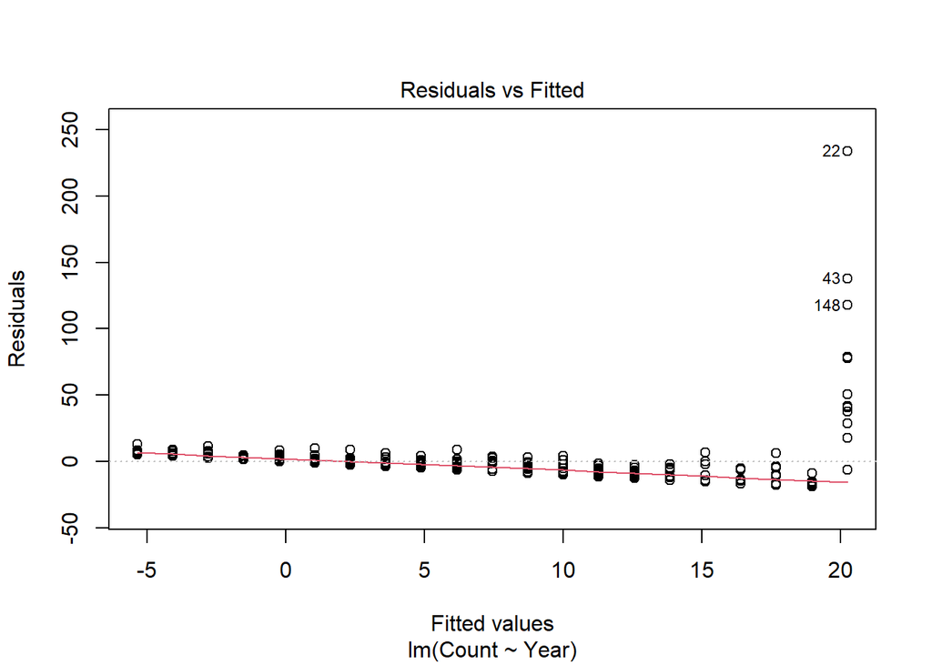

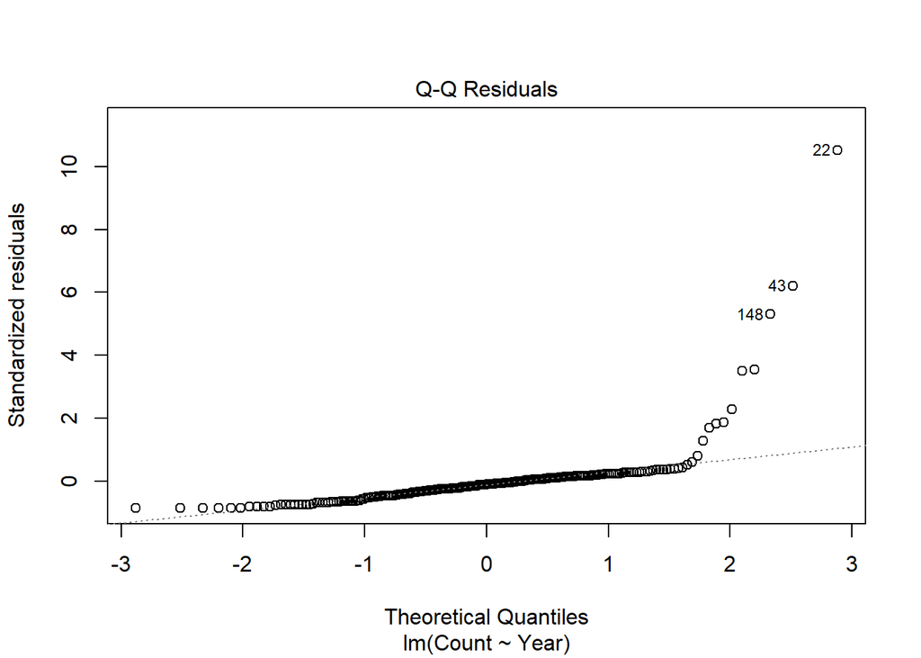

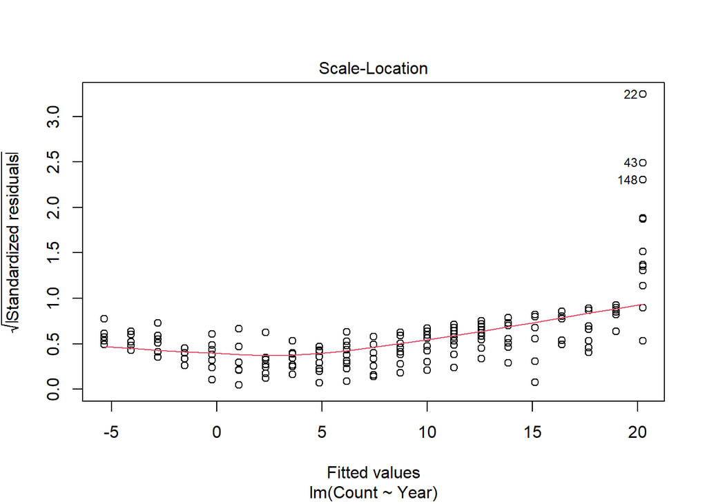

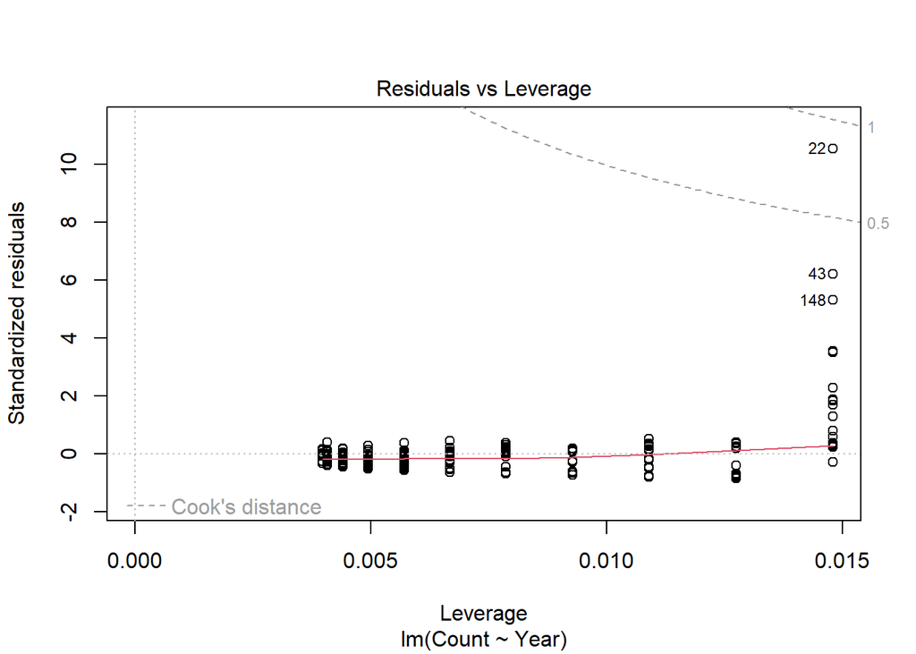

```r
plot(model1)
```

We can see that the this doesn’t exactly replicate the situation properly and we need an exponential regression for our problem.

Therefore we’re establishing another model to see, a negative binomial here because it allows for variance increase with the mean as Var(Count i)=μi+μi^2/θ. This means, we can use negative binomial to be modelled not with the count but with the expected value of the count. The notation goes like this: where expectation is E[Count i]=μi and therefore the previously established linear model becomes a bit different log(μ i)=β0+β1⋅Year i, where we have also made established a logarithmic relationship where μi=eβ0+β1⋅Year i.

```r
#Negative binomial with log transform.
library(MASS)
model2 <- glm.nb(Count ~ Year, link = "log", data = Data_long)

summary(model2)
```

```
##
## Call:
## glm.nb(formula = Count ~ Year, data = Data_long, link = "log",
##     init.theta = 0.5381569145)
##
## Coefficients:
##               Estimate Std. Error z value Pr(>|z|)
## (Intercept) -293.61244   31.33692  -9.370   <2e-16 ***
## Year           0.14639    0.01554   9.421   <2e-16 ***
## ---
## Signif. codes:  0 '***' 0.001 '**' 0.01 '*' 0.05 '.' 0.1 ' ' 1
##
## (Dispersion parameter for Negative Binomial(0.5382) family taken to be 1)
##
##     Null deviance: 393.30  on 251  degrees of freedom
## Residual deviance: 271.48  on 250  degrees of freedom
## AIC: 1305.3
##
## Number of Fisher Scoring iterations: 1
##
##
##               Theta:  0.5382
##           Std. Err.:  0.0573
##
##  2 x log-likelihood:  -1299.3060
```

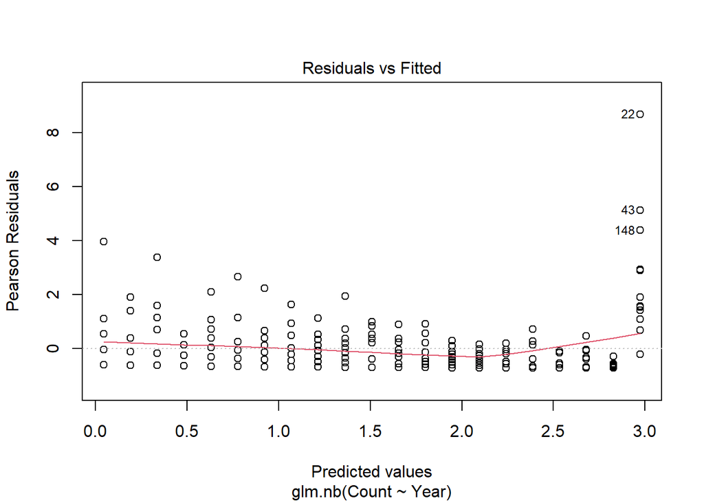

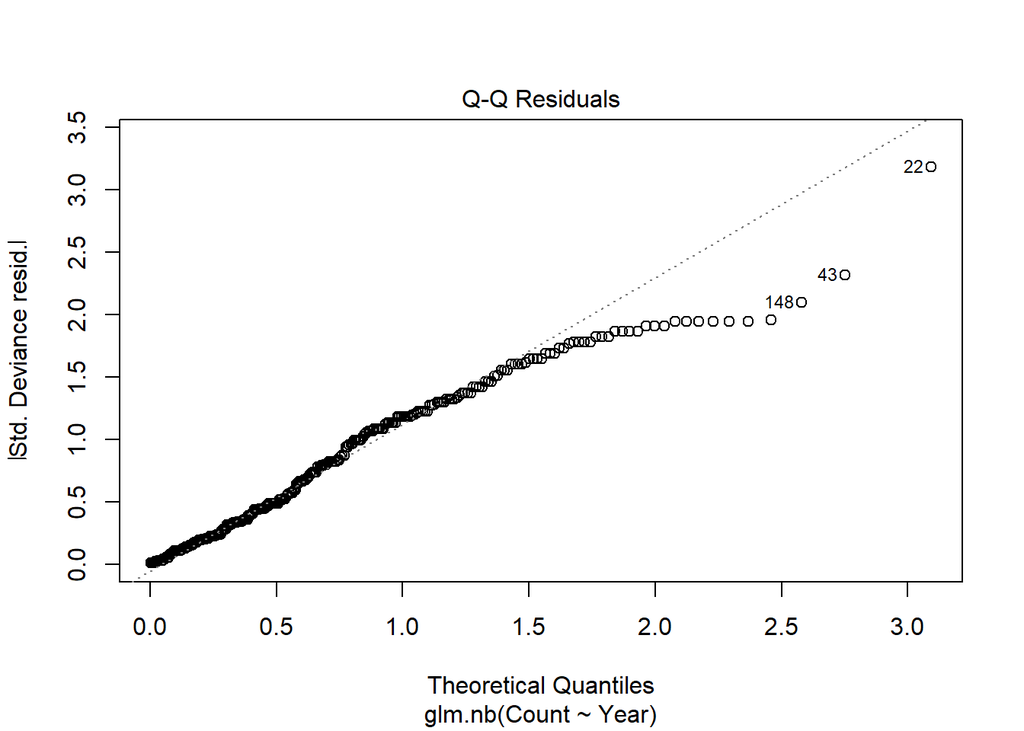

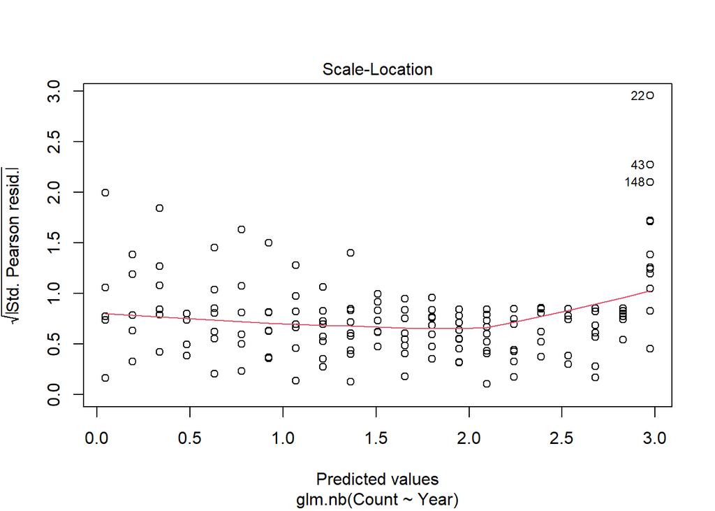

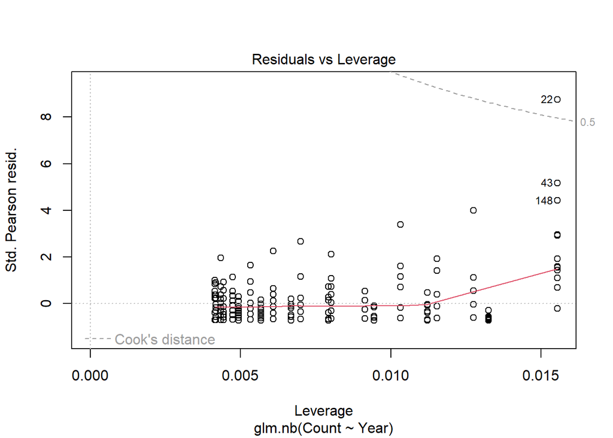

```r
plot(model2)
```

```r
#Seeing which model is more suitable with AIC test, lower value means better suitability and we get a lower value with model 2.
AIC(model1, model2)
```

```
##        df      AIC
## model1  3 2285.517
## model2  3 1305.306
```

We can see from the results of model 2 plot that the curve fit is better and the comparison of 2 models gives us an advantage with the generalized linear model with negative binomial.

Now we’re establishing the groundwork for the final plot, where we establish this notation η^=β0+β1⋅Year where SE(η^).

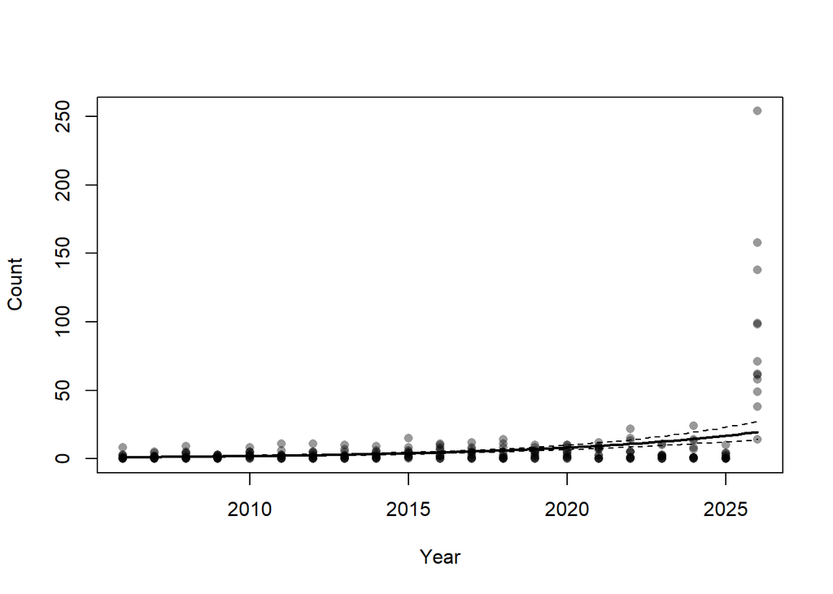

```r
#Creating data frame for years that space out evenly throughout 100 steps.
newdata <- data.frame(
  Year = seq(min(Data_long$Year), max(Data_long$Year), length.out = 100)
)

#Predict on link scale (non-linear relationship between expected value and response variable) with standard error.
pred <- predict(model2, newdata, type = "link", se.fit = TRUE)

#Conversion to exponents and back to response scale is done because η=log(μ) is transformed to μ=eη
fit <- exp(pred$fit)
upper <- exp(pred$fit + 1.96 * pred$se.fit)
lower <- exp(pred$fit - 1.96 * pred$se.fit)

#Plotting the data with curve fit following the equation μi=e^β0+e^β1*Year and dashed lines as error bars of it.
plot(Data_long$Year, Data_long$Count,
     pch = 16, col = rgb(0,0,0,0.4),
     xlab = "Year", ylab = "Count")

lines(newdata$Year, fit, lwd = 2)
lines(newdata$Year, upper, lty = 2)
lines(newdata$Year, lower, lty = 2)
```

## Result2

What we have modelled is an overall exponential growth of the registering of newer vehicles in 2026. Whilst 2026 has the most outliers, the data still represents that there is an ascending trend in registration of newer cars, which may mean that people prefer newer vehicles to the older ones due to need for higher maintenance.